# Comparison of round 1-4 data

Moses Kiti

2022-10-13

### Table 1: Compare characteristics of participants across rounds

Table showing the distribution of participant characteristics by company, age, sex, education level, family structure, race, Hispanic origins for round 1-4 of the survey.

**Table 1: Baseline characteristics of participants across rounds.**

|  | **Overall**, N = 1,456<sup>1</sup> | **Survey round** **One**, N = 304<sup>1</sup> | **Survey round** **Two**, N = 343<sup>1</sup> | **Survey round** **Three**, N = 376<sup>1</sup> | **Four**, N = 433<sup>1</sup> |  |
| --- | --- | --- | --- | --- | --- | --- |
| Company |  |  |  |  |  |  |
| Accenture | 485 (33%) | 39 (13%) | 24 (7%) | 127 (34%) | 295 (68%) |  |
| Emory 1599 | 206 (14%) | 87 (29%) | 37 (11%) | 41 (11%) | 41 (9%) |  |
| Guidehouse | 496 (34%) | 178 (59%) | 86 (25%) | 165 (44%) | 67 (15%) |  |
| Integral | 25 (2%) | 0 (0%) | 6 (2%) | 12 (3%) | 7 (2%) |  |
| Perkins & Will | 244 (17%) | 0 (0%) | 190 (55%) | 31 (8%) | 23 (5%) |  |
| Sex |  |  |  |  |  |  |
| Female | 933 (64%) | 184 (61%) | 227 (66%) | 248 (66%) | 274 (63%) |  |
| Male | 518 (36%) | 116 (38%) | 115 (34%) | 128 (34%) | 159 (37%) |  |
| Not reported | 5 (0%) | 4 (1%) | 1 (0%) | 0 (0%) | 0 (0%) |  |
| Age |  |  |  |  |  |  |
| 20-29 | 442 (30%) | 90 (30%) | 87 (25%) | 120 (32%) | 145 (33%) |  |
| 30-39 | 413 (28%) | 76 (25%) | 109 (32%) | 104 (28%) | 124 (29%) |  |
| 40-49 | 320 (22%) | 60 (20%) | 86 (25%) | 80 (21%) | 94 (22%) |  |
| 50-59 | 201 (14%) | 49 (16%) | 39 (11%) | 56 (15%) | 57 (13%) |  |
| 60+ | 80 (5%) | 29 (10%) | 22 (6%) | 16 (4%) | 13 (3%) |  |
| Education |  |  |  |  |  |  |
| Lower than Bachelors | 164 (11%) | 19 (6%) | 35 (10%) | 51 (14%) | 59 (14%) |  |
| Bachelors or higher | 1,291 (89%) | 284 (94%) | 308 (90%) | 325 (86%) | 374 (86%) |  |
| Family structure |  |  |  |  |  |  |
| Live alone | 222 (15%) | 44 (14%) | 43 (13%) | 60 (16%) | 75 (17%) |  |
| Nuclear | 919 (63%) | 173 (57%) | 241 (70%) | 236 (63%) | 269 (62%) |  |
| Extended | 138 (9%) | 26 (9%) | 27 (8%) | 40 (11%) | 45 (10%) |  |
| With roommates | 146 (10%) | 39 (13%) | 28 (8%) | 37 (10%) | 42 (10%) |  |
| Other | 31 (2%) | 22 (7%) | 4 (1%) | 3 (1%) | 2 (0%) |  |
| Race |  |  |  |  |  |  |
| Asian | 285 (20%) | 48 (16%) | 37 (11%) | 78 (21%) | 122 (28%) |  |
| Black | 134 (9%) | 26 (9%) | 30 (9%) | 35 (9%) | 43 (10%) |  |
| White | 909 (62%) | 174 (57%) | 256 (75%) | 241 (64%) | 238 (55%) |  |
| Mixed | 80 (5%) | 52 (17%) | 15 (4%) | 13 (3%) | 0 (0%) |  |
| Other | 48 (3%) | 4 (1%) | 5 (1%) | 9 (2%) | 30 (7%) |  |
| Hispanic | 95 (7%) | 14 (5%) | 20 (6%) | 24 (6%) | 37 (9%) |  |

<sup>*1*</sup> n (%)

### Table 2: Compare characteristics of contacts across rounds

**Table 2: Characteristics of contacts across rounds.**

|  | **Overall**, N = 12,198<sup>1</sup> | **Survey round** **One**, N = 1,548<sup>1</sup> | **Survey round** **Two**, N = 2,814<sup>1</sup> | **Survey round** **Three**, N = 3,444<sup>1</sup> | **Four**, N = 4,392<sup>1</sup> |  |
| --- | --- | --- | --- | --- | --- | --- |
| Age of contact |  |  |  |  |  |  |
| 0-9 | 799 (7%) | 139 (9%) | 205 (7%) | 226 (7%) | 229 (5%) |  |
| 10-19 | 885 (7%) | 130 (8%) | 207 (7%) | 291 (8%) | 257 (6%) |  |
| 20-29 | 3,229 (26%) | 379 (24%) | 663 (24%) | 943 (27%) | 1,244 (28%) |  |
| 30-39 | 2,713 (22%) | 302 (20%) | 621 (22%) | 741 (22%) | 1,049 (24%) |  |
| 40-59 | 3,460 (28%) | 444 (29%) | 830 (29%) | 941 (27%) | 1,245 (28%) |  |
| 60+ | 1,112 (9%) | 154 (10%) | 288 (10%) | 302 (9%) | 368 (8%) |  |
| Sex of contact |  |  |  |  |  |  |
| Female | 6,143 (50%) | 754 (49%) | 1,336 (47%) | 1,830 (53%) | 2,223 (51%) |  |
| Male | 5,823 (48%) | 793 (51%) | 1,432 (51%) | 1,526 (44%) | 2,072 (47%) |  |
| Not reported | 232 (2%) | 1 (0%) | 46 (2%) | 88 (3%) | 97 (2%) |  |
| Type of contact |  |  |  |  |  |  |
| Conversation | 5,872 (48%) | 845 (55%) | 1,470 (52%) | 1,790 (52%) | 1,767 (40%) |  |
| Physical | 4,417 (36%) | 703 (45%) | 1,019 (36%) | 1,041 (30%) | 1,654 (38%) |  |
| Proximity | 1,909 (16%) | 0 (0%) | 325 (12%) | 613 (18%) | 971 (22%) |  |
| Location of contact |  |  |  |  |  |  |
| Community | 6,036 (49%) | 456 (29%) | 1,327 (47%) | 1,947 (57%) | 2,306 (53%) |  |
| Home | 4,515 (37%) | 996 (64%) | 1,206 (43%) | 1,076 (31%) | 1,237 (28%) |  |
| Work | 1,647 (14%) | 96 (6%) | 281 (10%) | 421 (12%) | 849 (19%) |  |
| contact_duration |  |  |  |  |  |  |
| <5 mins | 2,800 (23%) | 303 (20%) | 697 (25%) | 801 (23%) | 999 (23%) |  |
| 5-15 mins | 1,590 (13%) | 188 (12%) | 358 (13%) | 413 (12%) | 631 (14%) |  |
| 15 mins-1 hr | 1,769 (15%) | 157 (10%) | 348 (12%) | 534 (16%) | 730 (17%) |  |
| 1-4 hrs | 2,699 (22%) | 315 (20%) | 521 (19%) | 860 (25%) | 1,003 (23%) |  |
| 4+ hrs | 3,339 (27%) | 584 (38%) | 890 (32%) | 836 (24%) | 1,029 (23%) |  |

<sup>*1*</sup> n (%)

### Table 3: Average contacts by round

[output not shown]

### Graphs of contacts by select covariates

The figure below shows the distribution of contacts by age for rounds 1-4.

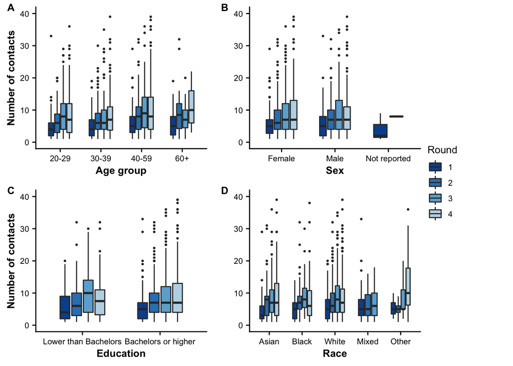

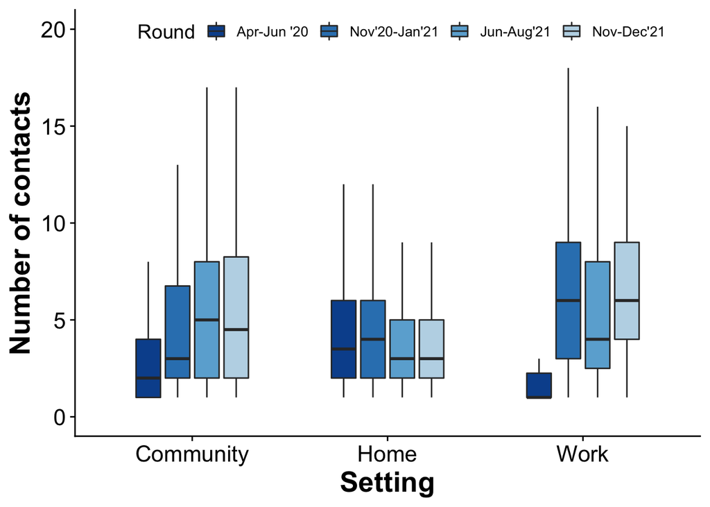

# Median contactsat work, home and community by round

```
# A tibble: 12 × 8
# Groups:   round [4]
   round contact_location count  mean    sd median    q1    q3
   <fct> <chr>            <int> <dbl> <dbl>  <dbl> <dbl> <dbl>
 1 One   Community          145  3.14  2.61    2    1      4
 2 One   Home               242  4.12  2.77    3.5  2      6
 3 One   Work                14  6.86  9.80    1    1     10.5
 4 Two   Community          231  5.74  7.14    4    2      7
 5 Two   Home               286  4.22  2.70    4    2      6
 6 Two   Work                41  6.85  4.72    6    3      9
 7 Three Community          300  6.49  6.20    5    2      9
 8 Three Home               289  3.72  2.93    3    2      5
 9 Three Work                68  6.19  5.40    4.5  2.75   8
10 Four  Community          322  7.16  7.54    5    2      9
11 Four  Home               340  3.64  2.69    3    2      5
12 Four  Work                91  9.33  9.87    6    4     10
```

### Comparison of median (IQR) contacts by round.

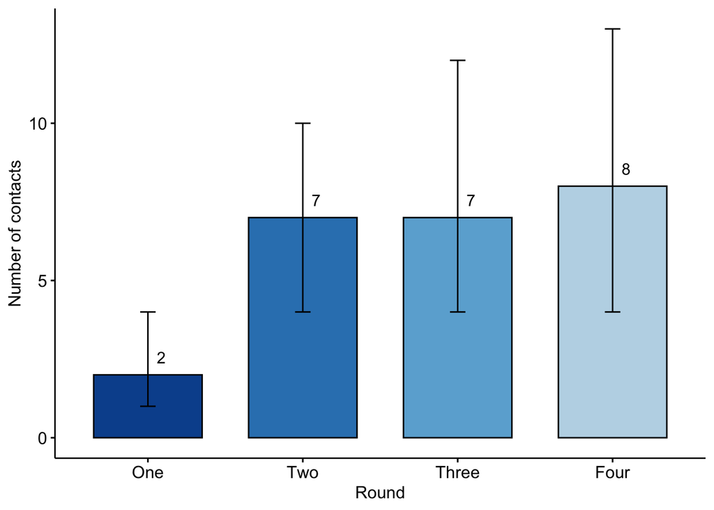

The median (IQR) contact rates for round 1, 2, 3 and 4 were 2 (1, 4),  
7 (4, 10), 7 (4, 12), and 8 (4, 13), respectively.

### Matrices by study round

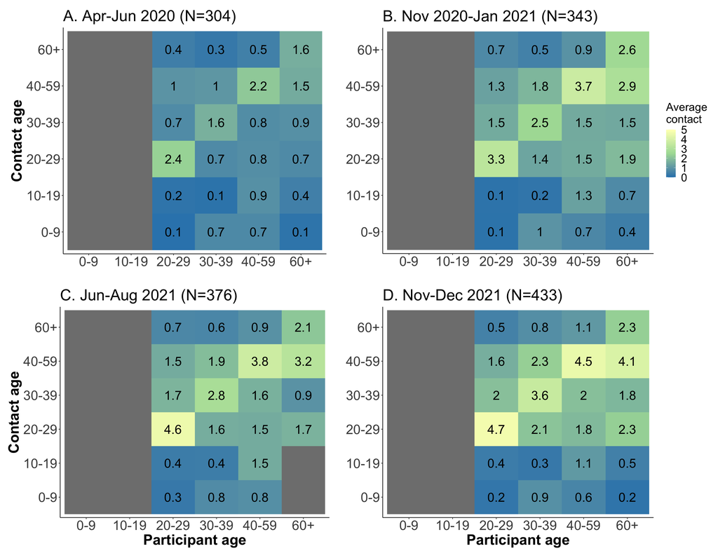

### Matrices by location of contact

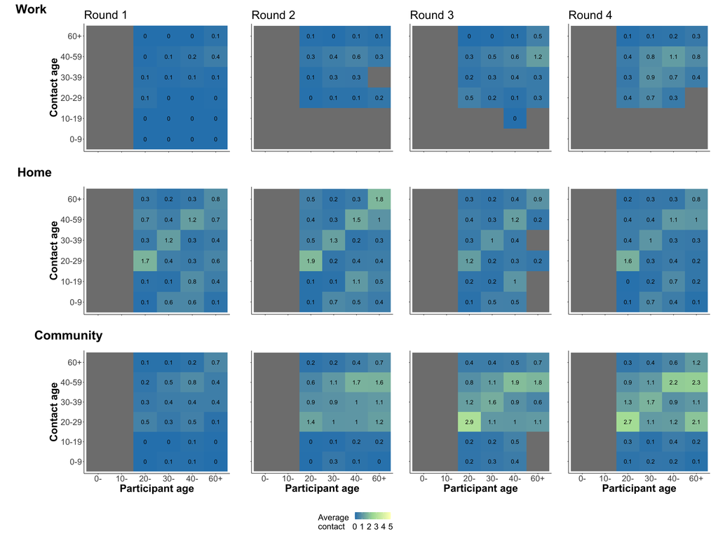

### Weighted mixing matrices

Weighting is done to generate a contact matrix that is generaliable to the US workforce population. We extract employee data from the US Bureau of Labor Statistics (2020 data). Then, we extract employee numbers for the following categorizations: “management occupations”, “business and financial operations occupations”, “computer and mathematical occupations” and “life physical and social science occupations”. These categories represent the job categories for the companies that have participated in our survey. However, the employment data are in discrete age groups (20, 21,…, 80) which is different to our questionnaire data (4 age groups). Hence, we adjust the employee population age categories to match the survey age categories as explained below: a) let total number of employees per age category = n(a); let the number of discrete ages per age category be a(i) e.g. for 20-24, i=20,21,22,23,24, etc; let number of discrete ages per age category be n_a(i); b) let number of people per discrete age be p(i), then, p(i) = n_a(i)/a(i) c) to re-categorize for survey data, sum up p(i) for all age categories.

This has been done in Excel, data available in this file: “us_company_weights_052021.csv”

### Difference matrices among employees only

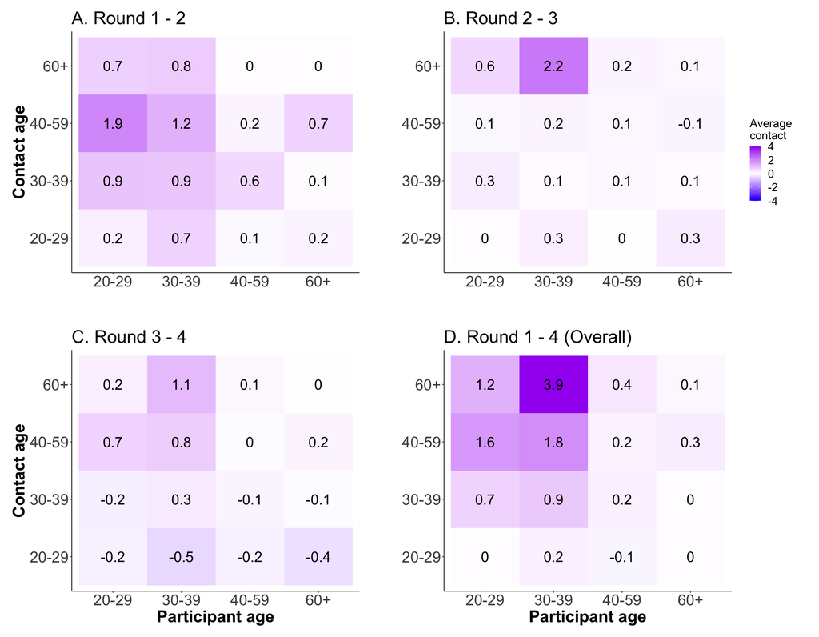